# 1 Enquête FEDORU

La FEDORU a décidé de faire sa propre enquête concernant les logiciels utilisés dans les servives d’urgence. RESURAL a été chargé de cette enquête.

## 1.1 Correspondants

| Qui | Tel. | Organisme |
| --- | --- | --- |
| Caroline LEGLOAN | 01 40 56 55 45 | DGOS |
| Mary LATOUILLE |  | DGOS |
| Gilles VIUDES |  | FEDORU |
| Vaniba BOUSQUET |  | InVS |

## 1.2 Méthodologie

La liste des SU a été récupérée à partir du fichier FINESS en sélectionnant toutes les régions de France + médecine d’urgence. L’export se fait en utilisabt le format étendu. Le fichier résultant est enregistré sous **DATA/SU_France_2014.csv**. A partir de ce fichier, les colonnes … ont été isolées. Le fichier obtenu a été mis en ligne via **google drive** et mis à la disposition des membres du CA.

Une liste des logiciels se trouve sur le site officiel du [DMP](http://www.dmp.gouv.fr/dmp-compatibilite). **Agnès** se charge de faire un tri dans les logiciels.

Google ayant modifié les conditions d’accès au *drive*, il faut procéder en trois temps pour récupérer les données:

1. ouvrir le fichier dans drive et importer le fichier au format .csv.
2. l’ouvrir dans calc et le réenregisterer au format .csv en précisant que les champs doivent être entourés de guillemets (sinon ça plante)
3. transférer le ficher dans le répertoire de travail et le renommer **su_France_ + AAAAMMJJ + .csv**.

```
##  [1] "X"                       "Région"
##  [3] "Dpt"                     "FINNES"
##  [5] "Raison.sociale"          "Complement.distribution"
##  [7] "Adresse"                 "Lieudit.BP"
##  [9] "Code.postal"             "Libelle.routage"
## [11] "Tel"                     "nom.correspondant"
## [13] "mail"                    "logiciel"
## [15] "editeur"                 "RPU..OUI.NON."
## [17] "Remarque"
```

```
## 'data.frame':    671 obs. of  17 variables:
##  $ X                      : int  437 438 439 440 441 442 443 444 445 446 ...
##  $ Région                 : Factor w/ 23 levels "ALSACE","AQUITAINE",..: 1 1 1 1 1 1 1 1 1 1 ...
##  $ Dpt                    : Factor w/ 99 levels "Ain","Aine","Allier",..: 12 12 12 12 12 12 12 12 12 37 ...
##  $ FINNES                 : Factor w/ 664 levels "","100000090",..: 399 400 401 402 403 404 405 406 407 408 ...
##  $ Raison.sociale         : Factor w/ 661 levels "AMERICAN MEMORIAL HOSPITAL CHU REIMS",..: 523 87 341 292 127 472 435 473 525 436 ...
##  $ Complement.distribution: Factor w/ 50 levels "","2-avr.","3-juin",..: 1 1 1 1 1 1 1 1 1 1 ...
##  $ Adresse                : Factor w/ 650 levels "","1 ALLEE DU CHATEAU",..: 19 437 163 242 239 431 212 156 9 50 ...
##  $ Lieudit.BP             : Factor w/ 296 levels "","2 AV DU 11 NOVEMBRE 1918",..: 157 148 76 74 120 1 244 1 1 31 ...
##  $ Code.postal            : Factor w/ 647 levels "1000","10003",..: 384 389 391 387 390 386 383 383 385 396 ...
##  $ Libelle.routage        : Factor w/ 602 levels "ABBEVILLE CEDEX",..: 541 240 479 601 482 540 541 541 542 377 ...
##  $ Tel                    : Factor w/ 647 levels "","01 30 63 85 90",..: 345 344 351 349 350 347 346 348 345 355 ...
##  $ nom.correspondant      : Factor w/ 281 levels "","\nDominique CALAFAT\nPhilippe GODARD\n",..: 1 1 1 1 1 1 1 1 1 1 ...
##  $ mail                   : Factor w/ 397 levels "","à vérifier",..: 1 1 1 1 1 1 1 1 1 1 ...
##  $ logiciel               : Factor w/ 94 levels "","\nEQUAFILE",..: 31 66 31 7 12 31 7 58 31 7 ...
##  $ editeur                : Factor w/ 47 levels "","\n","- EASILY en 2015",..: 1 1 1 1 1 1 1 1 1 1 ...
##  $ RPU..OUI.NON.          : Factor w/ 12 levels "","\n"," OUI",..: 9 9 9 9 9 9 9 9 9 9 ...
##  $ Remarque               : Factor w/ 37 levels "","\n","- (ORBIS)",..: 1 1 1 1 1 1 6 1 1 1 ...
```

#### 1.2.0.1 Normalisation du fichier

- Suppression des blancs
- suppression des caractères accentués
- correction du nom des logiciels (+++)
- CENTRE HOSPITALIER DE GONESSE volontairement dupliqué car 2 SU avec 2 logiciels différents
- CENTRE HOSPITALIER M JACQUET MELUN idem
- ORSAY idem
- Si pas de SU on met NA dans la colonne logiciel

#### 1.2.0.2 Nombre (théorique) de SU par région:

```
              ALSACE            AQUITAINE             AUVERGNE
                  19                   35                   15
     BASSE NORMANDIE            BOURGOGNE             BRETAGNE
                  23                   23                   32
              CENTRE   CHAMPAGNE ARDENNES                CORSE
                  28                   16                    8
                 DOM        FRANCHE CONTE      HAUTE NORMANDIE
                  14                   13                   21
       ILE DE France LANGUEDOC ROUSSILLON             LIMOUSIN
                  99                   29                   10
            LORRAINE        MIDI PYRENEES   NORD PAS DE CALAIS
                  23                   37                   37
                PACA     PAYS DE LA LOIRE             PICARDIE
                  52                   21                   21
   POITOU CHANRENTES          RHONE ALPES
                  24                   71
```

```
   Min. 1st Qu.  Median    Mean 3rd Qu.    Max.
   8.00   17.50   23.00   29.17   33.50   99.00
```

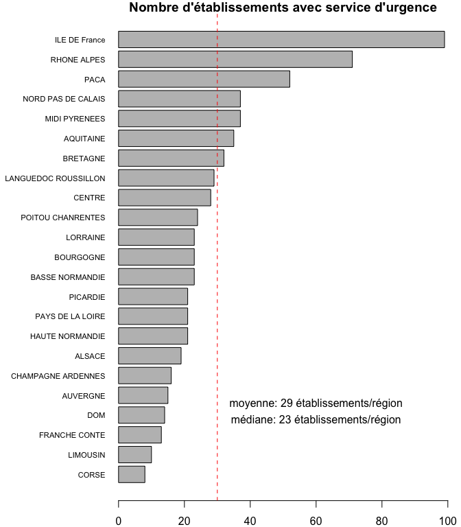

#### 1.2.0.3 Table des logiciels répertoriés

On exclu les colonnes:

- “MAIL ENVOYÉ SUR LE SITE RUBRIQUE NOUS CONTACTER” (28)
- “MAIL ATTENTE REPONSE” (27)
- “NON INFORMATISÉ” (39)

[output not shown]

[output not shown]

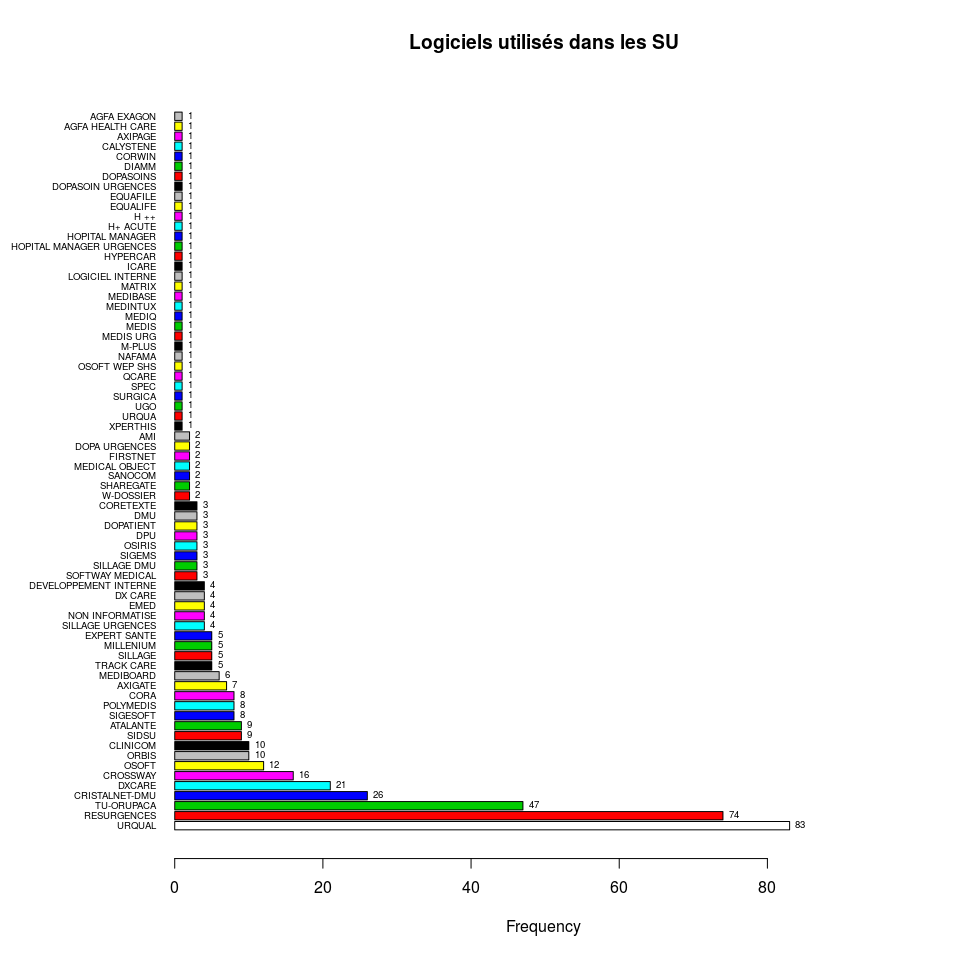

[figure not shown]

```
l :
                         Frequency   %(NA+)   %(NA-)
AGFA EXAGON                      1      0.2      0.2
AGFA HEALTH CARE                 1      0.2      0.2
AXIPAGE                          1      0.2      0.2
CALYSTENE                        1      0.2      0.2
CORWIN                           1      0.2      0.2
DIAMM                            1      0.2      0.2
DOPASOIN URGENCES                1      0.2      0.2
DOPASOINS                        1      0.2      0.2
EQUAFILE                         1      0.2      0.2
EQUALIFE                         1      0.2      0.2
H ++                             1      0.2      0.2
H+ ACUTE                         1      0.2      0.2
HOPITAL MANAGER                  1      0.2      0.2
HOPITAL MANAGER URGENCES         1      0.2      0.2
HYPERCAR                         1      0.2      0.2
ICARE                            1      0.2      0.2
LOGICIEL INTERNE                 1      0.2      0.2
M-PLUS                           1      0.2      0.2
MATRIX                           1      0.2      0.2
MEDIBASE                         1      0.2      0.2
MEDINTUX                         1      0.2      0.2
MEDIQ                            1      0.2      0.2
MEDIS                            1      0.2      0.2
MEDIS URG                        1      0.2      0.2
NAFAMA                           1      0.2      0.2
OSOFT WEP SHS                    1      0.2      0.2
QCARE                            1      0.2      0.2
SPEC                             1      0.2      0.2
SURGICA                          1      0.2      0.2
UGO                              1      0.2      0.2
URQUA                            1      0.2      0.2
XPERTHIS                         1      0.2      0.2
AMI                              2      0.4      0.4
DOPA URGENCES                    2      0.4      0.4
FIRSTNET                         2      0.4      0.4
MEDICAL OBJECT                   2      0.4      0.4
SANOCOM                          2      0.4      0.4
SHAREGATE                        2      0.4      0.4
W-DOSSIER                        2      0.4      0.4
CORETEXTE                        3      0.5      0.6
DMU                              3      0.5      0.6
DOPATIENT                        3      0.5      0.6
DPU                              3      0.5      0.6
OSIRIS                           3      0.5      0.6
SIGEMS                           3      0.5      0.6
SILLAGE DMU                      3      0.5      0.6
SOFTWAY MEDICAL                  3      0.5      0.6
DEVELOPPEMENT INTERNE            4      0.7      0.9
DX CARE                          4      0.7      0.9
EMED                             4      0.7      0.9
NON INFORMATISE                  4      0.7      0.9
SILLAGE URGENCES                 4      0.7      0.9
EXPERT SANTE                     5      0.9      1.1
MILLENIUM                        5      0.9      1.1
SILLAGE                          5      0.9      1.1
TRACK CARE                       5      0.9      1.1
MEDIBOARD                        6      1.1      1.3
AXIGATE                          7      1.3      1.5
CORA                             8      1.5      1.7
POLYMEDIS                        8      1.5      1.7
SIGESOFT                         8      1.5      1.7
ATALANTE                         9      1.6      1.9
SIDSU                            9      1.6      1.9
CLINICOM                        10      1.8      2.2
ORBIS                           10      1.8      2.2
OSOFT                           12      2.2      2.6
CROSSWAY                        16      2.9      3.4
DXCARE                          21      3.8      4.5
CRISTALNET-DMU                  26      4.7      5.6
TU-ORUPACA                      47      8.5     10.1
RESURGENCES                     74     13.4     15.9
URQUAL                          83     15.1     17.9
<NA>                            87     15.8      0.0
  Total                        551    100.0    100.0
```

Nombre total de SU identifiés: 584

Nombre total de logiciels identifiés: 464

Taux d’exhaustivité: 79.45 %

Nombre de fournisseurs identifiés: 72

SU non informatisés: 4

SU contactés en attente de réponse: 120

#### 1.2.0.4 Table logiciels par région:

```
                         ALSACE AQUITAINE AUVERGNE BASSE NORMANDIE
AGFA EXAGON                   0         0        0               0
AGFA HEALTH CARE              0         0        0               0
AMI                           0         0        0               0
ATALANTE                      7         0        0               1
AXIGATE                       0         1        0               2
AXIPAGE                       0         0        0               0
CALYSTENE                     0         0        0               0
CLINICOM                      1         1        0               0
CORA                          0         0        0               1
CORETEXTE                     0         0        0               0
CORWIN                        0         0        0               0
CRISTALNET-DMU                3         0        0               1
CROSSWAY                      0         3        0               0
DEVELOPPEMENT INTERNE         0         0        0               0
DIAMM                         0         0        0               0
DMU                           0         0        0               0
DOPA URGENCES                 0         0        0               0
DOPASOIN URGENCES             0         0        0               0
DOPASOINS                     0         1        0               0
DOPATIENT                     0         0        0               0
DPU                           0         0        0               0
DX CARE                       0         0        0               0
DXCARE                        4         5        0               0
EMED                          0         0        0               0
EQUAFILE                      0         0        0               0
EQUALIFE                      0         0        0               0
EXPERT SANTE                  0         0        0               0
FIRSTNET                      0         0        0               0
H ++                          0         0        0               0
H+ ACUTE                      0         0        0               0
HOPITAL MANAGER               0         0        0               0
HOPITAL MANAGER URGENCES      0         0        0               0
HYPERCAR                      0         0        0               0
ICARE                         0         0        0               0
LOGICIEL INTERNE              0         0        0               0
M-PLUS                        0         1        0               0
MATRIX                        0         0        1               0
MEDIBASE                      0         1        0               0
MEDIBOARD                     0         0        0               0
```

[output cut: 453 more lines]

```
SIGEMS                             0
SIGESOFT                           0
SILLAGE                            0
SILLAGE DMU                        0
SILLAGE URGENCES                   0
SOFTWAY MEDICAL                    0
SPEC                               0
SURGICA                            0
TRACK CARE                         0
TU-ORUPACA                         0
UGO                                0
URQUA                              0
URQUAL                             1
W-DOSSIER                          0
XPERTHIS                           0
```

#### 1.2.0.5 Comparaison nb SU/Logiciels par région

- SU: nombre de services d’urgence
- Logiciels: nombre de logiciels répertorié (au 1/9/2014)
- Rapport: % d’équipement

```
                     Logiciels SU rapport reg.id
ALSACE                      18 18  100.00     42
AQUITAINE                   35 35  100.00     72
AUVERGNE                     4 12   33.33     83
BASSE NORMANDIE             12 19   63.16     25
BOURGOGNE                   21 21  100.00     26
BRETAGNE                    31 32   96.88     53
CENTRE                       7 22   31.82     24
CHAMPAGNE ARDENNES          16 16  100.00     21
CORSE                        4  4  100.00     94
DOM                          2 13   15.38    100
FRANCHE CONTE               13 13  100.00     43
HAUTE NORMANDIE              8 14   57.14     23
ILE DE France               89 89  100.00     11
LANGUEDOC ROUSSILLON        28 28  100.00     91
LIMOUSIN                    10 10  100.00     74
LORRAINE                    23 23  100.00     41
MIDI PYRENEES               30 30  100.00     73
NORD PAS DE CALAIS          27 27  100.00     31
PACA                        48 48  100.00     93
PAYS DE LA LOIRE            11 16   68.75     52
PICARDIE                     1 17    5.88     22
POITOU CHANRENTES            2 19   10.53     54
RHONE ALPES                 20 58   34.48     82
```

```
                     Logiciels SU rapport reg.id
PICARDIE                     1 17    5.88     22
POITOU CHANRENTES            2 19   10.53     54
DOM                          2 13   15.38    100
CENTRE                       7 22   31.82     24
AUVERGNE                     4 12   33.33     83
RHONE ALPES                 20 58   34.48     82
HAUTE NORMANDIE              8 14   57.14     23
BASSE NORMANDIE             12 19   63.16     25
PAYS DE LA LOIRE            11 16   68.75     52
BRETAGNE                    31 32   96.88     53
ALSACE                      18 18  100.00     42
AQUITAINE                   35 35  100.00     72
BOURGOGNE                   21 21  100.00     26
CHAMPAGNE ARDENNES          16 16  100.00     21
CORSE                        4  4  100.00     94
FRANCHE CONTE               13 13  100.00     43
ILE DE France               89 89  100.00     11
LANGUEDOC ROUSSILLON        28 28  100.00     91
LIMOUSIN                    10 10  100.00     74
LORRAINE                    23 23  100.00     41
MIDI PYRENEES               30 30  100.00     73
NORD PAS DE CALAIS          27 27  100.00     31
PACA                        48 48  100.00     93
```

- nombre de logiciels répertoriés: 460
- nombre de services répertoriés: 584 . Le nombre de SU est surestimé par le répertoire FINESS (par ex. des établissements sans SU mais avec une antenne SMUR saisonnière y figurent).

Comparer public, privé et PSPH

# 2 Cartographie

```
[1] "reg.id"    "reg.nom"   "x"         "y"         "Logiciels" "SU"
[7] "rapport"
```

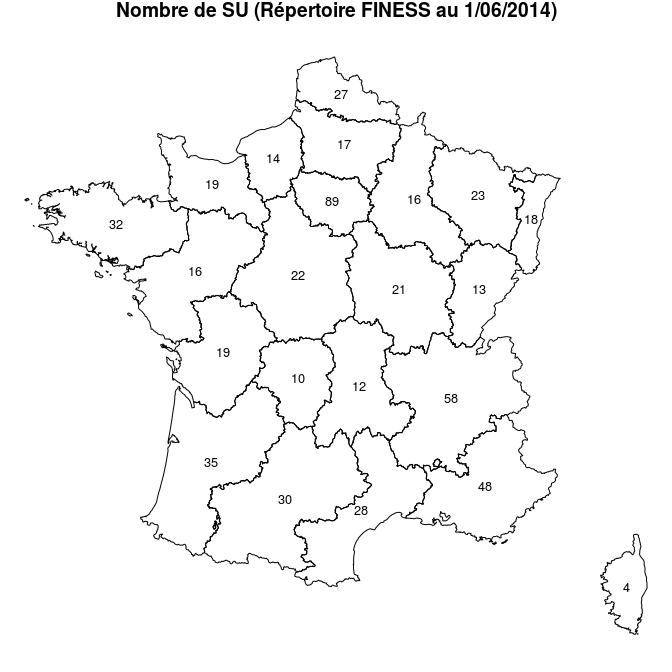

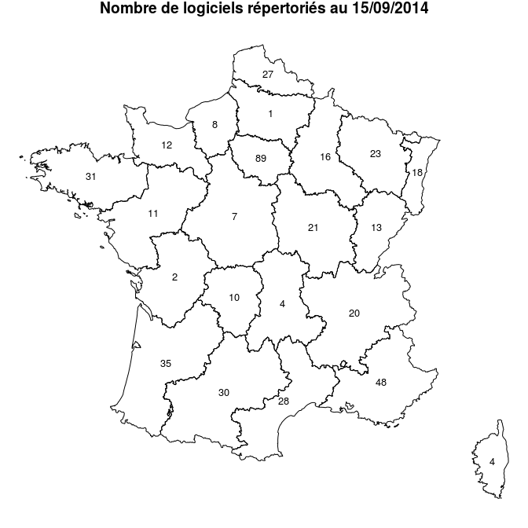

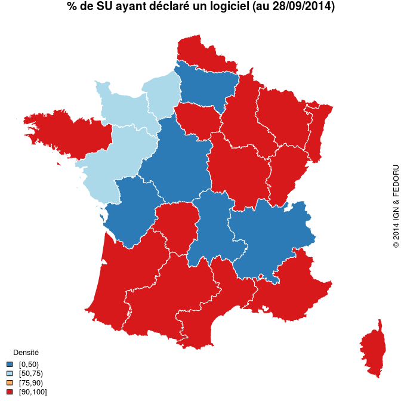

[figure not shown]

[figure not shown]

[figure not shown]

## 2.1 Transmission des RPU

```
      NA      NON      OUI OUI\nNON
     125       49      409        1
```

[output not shown]

[output cut: 24 more lines]

```
AGFA HEALTH CARE                                  0       0  NaN
CALYSTENE                                         0       0  NaN
DOPASOIN URGENCES                                 0       0  NaN
EQUAFILE                                          0       0  NaN
H ++                                              0       0  NaN
HOPITAL MANAGER                                   0       0  NaN
HOPITAL MANAGER URGENCES                          0       0  NaN
ICARE                                             0       0  NaN
LOGICIEL INTERNE                                  0       0  NaN
MAIL ENVOYE SUR LE SITE RUBRIQUE NOUS CONTACTER   0       0  NaN
MEDIQ                                             0       0  NaN
OSOFT WEP SHS                                     0       0  NaN
SOFTWAY MEDICAL                                   0       0  NaN
SURGICA                                           0       0  NaN
UGO                                               0       0  NaN
```

# 3 Table logiciels - Finess

```r
a <- d[, c("FINNES", "logiciel")]
a <- a[!is.na(a$logiciel),]
a <- a[a$logiciel != "MAIL ATTENTE REPONSE",]
a <- a[a$logiciel != "NON INFORMATISE",]
a <- a[a$logiciel != "MAIL ENVOYE SUR LE SITE RUBRIQUE NOUS CONTACTER",]
names(a) <- c("FINESS_GEO", "LOGICIEL")
write.csv2(a, file="logiciels_Finess_20140927.csv", row.names = FALSE)

# le top ten
x <- tab1(a$LOGICIEL, missing=FALSE, sort.group = "increasing", cex = 0.6, cex.names = 0.6, main="Logiciels utilisés dans les SU")
```

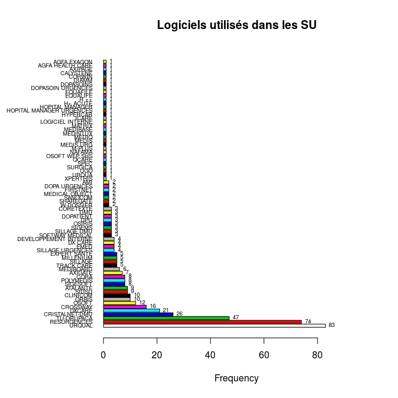

[figure not shown]

```r
x1 <- x$output.table
x2 <- tail(x1, 11)
x2 <- x2[-11,]
x2[order(x2[,1], decreasing = TRUE),]
```

```
##                Frequency Percent Cum. percent
## URQUAL                83    18.0        100.0
## RESURGENCES           74    16.1         82.0
## TU-ORUPACA            47    10.2         65.9
## CRISTALNET-DMU        26     5.7         55.7
## DXCARE                21     4.6         50.0
## CROSSWAY              16     3.5         45.4
## OSOFT                 12     2.6         42.0
## CLINICOM              10     2.2         37.2
## ORBIS                 10     2.2         39.3
## SIDSU                  9     2.0         35.0
```

```r
top10 <- sum(x2[,2]) # % représenté par les 10 premiers
```

# 4 Table Régionales